# Report: Act Report

# Introduction

Preparing data is not an easy part in the data analysis task, after going through the Assessing phase where we identified quakity and tidiness issues and the Data Cleaning phase where we fixed the issues observed from the Assessing phase we the move to the part where we put the clean data to good use by creating data driven insights and visualizations.

## Insight 1:

> What dog names are the most common?

There is a column that has the name of various dogs used in the tweets, then we did a simple `value_count()` to find the name that is most common among all the valid names. Although a great amount of entries did not use a valid name, we could see the most common names that are been used.

**Cooper** was the name that was the most common.

## Insight 2:

> What dog breeds are the Most Rated?

There are columns that contains the breed of dogs and also the rating, the question poised was to find out what breed has the highest ratings.

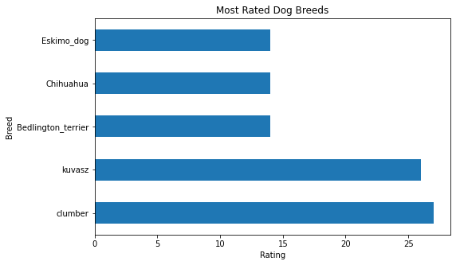

And we found that the **Clumber** breed has the highest rating.

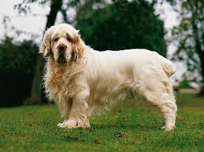

## Insight 3

> What dog breed has the most retweet count?

This question was poised to determine the dog breed that people liked the most. A retweet is proof enough of identifying the interest of people. We show a bar plot of our findings.

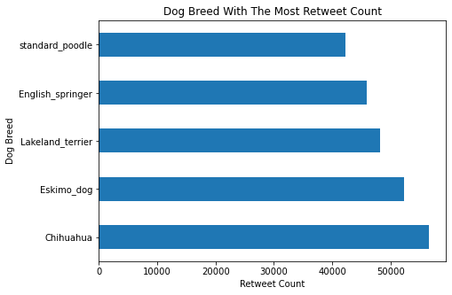

The **Chihuahua** has the most retweet

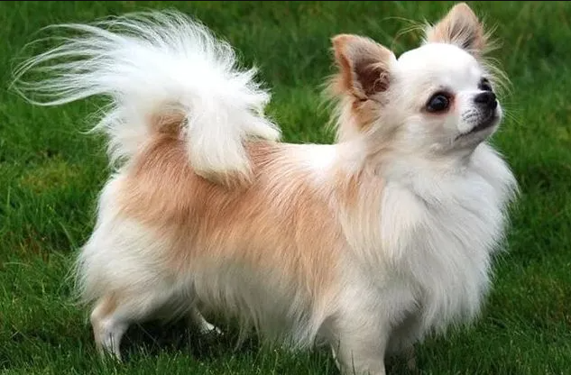

## Insight 4

> What is the most common dog stage?

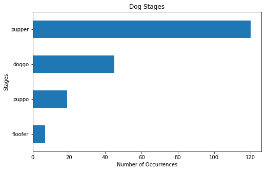

The **Pupper** is the most common dog stage